# Discount - Sales Analysis

Merly Varghese

## What is linear regression ?

Linear regression is a commonly used technique in predictive analytics, which build a model to explain the change in one variable based on the linear relationship with other variables. Linear Regression can be classified as follows:

- *Simple Linear Regression* : A single variable can explain the change in the dependent variable.
- *Multiple Linear Regression* : Change in the dependent variable can be explained by multiple variables.

## About Data

Data used for this analysis is the dummy data generated for sales of different category of items in an outlet. The column names are described below

- *UPC* : Unique Product Code of the item
- *Category* : Category name. The categories included in the data are Vegetable & fruits, meat & fish , snacks, diary and Care products.
- *Price* : Price per unit of the item ( INR)
- *Discount* : Discount applied for the item.(%)
- *Sales* : Total sales recorded for the item after the discount applied (INR)

## Objective

Analyze how percentage of discount influence the product sales in different categories and predict sales using the data provided

## Data exploration

In the data, all categories have around 80 unique items and the plot given below explains the combined sales of products across all categories.

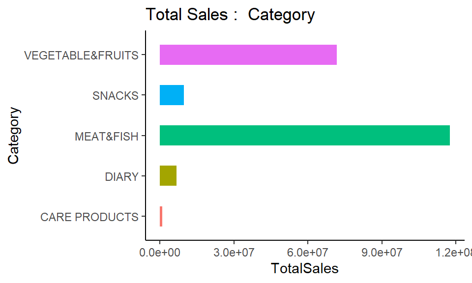

The major part of the sales is made by food products such as Vegetable & Fruits and Meat &fish. Items under the category care products has comparatively less sales among all the categories.

## Category Wise Analysis

### VEGETABLE&FRUITS

Linear model equation :

$$Sales = 1.5\times 10^{4} * Price + 125
* Discount + 1123$$

$$Adjusted R-squre = 100$$
**Conclusion** :

Discount has a positive correlation with the sales.ie, as Discount increases, a similar increasing trend visible in sales.

### SNACKS

Linear model equation :

$$Sales = 487 * Price + -3046 * Discount
+ 1.10341\times 10^{5}$$

$$Adjusted Rsqure = 13$$

### MEAT&FISH

Linear model equation :

$$Sales = 10^{4} * Price + -435 *
Discount + 123$$

$$Adjusted Rsqure = 100$$

### CARE PRODUCTS

Linear model equation :

$$Sales = 1 * Price + 1 * Discount +
1.1454\times 10^{4}$$

$$Adjusted Rsqure = 100$$

### DIARY

Linear model equation :

$$Sales = 1000 * Price + -10 * Discount +
145$$

$$Adjusted Rsqure = 100$$